# Analiza oferty Hebe - Pielęgnacja Koreańska

1 grudnia 2024

# Wstęp

Pielęgnacja koreańska w ostatnich latach bardzo zyskała na popularności na całym świecie dzięki swojemu kompleksowemu podejściu do pielęgnacji skóry. Opiera się na zasadach wieloetapowej rutyny, która ma na celu zapewnienie nawilżania, ochrony i regeneracji skóry.

Drogeria Hebe oferuje szeroką gamę produktów z zakresu pielęgnacji koreańskiej. Zapewnia to dobrą bazę danych do objęcia analizą pod kątem asortymentu, cen oraz popularności wśród klientów.

Celem analizy jest:

1. Zbadanie tej kategorii pod kątem cenowym
2. Zapoznanie się z najczęściej oferowanymi produktami
3. Wytypowanie 5 najbardziej popularnych marek i zapoznanie się z ich polityką cenową
4. Poznanie oferty najpopularniejszej marki
5. Analiza top 10 najbardziej popularnych produktow
6. Przeanalizowanie ofert tej kategorii pod kątem występowania w nich potencjalnych alergenów

*Wczytanie bibliotek i danych do analizy*

```r
#Biblioteki
library(ggplot2)
library(readr)
library(dplyr)
library(gt)
library(tidyr)

# Dane do analizy
dane_df <- read_csv("Hebe.csv")
```

# Analizy

## 1. Rozkład cen dla produktów z kategorii *pielęgnacja koreańska*

Analiza rozkładu cen produktów z kategorii “pielęgnacja koreańska” pozwala na lepsze zrozumienie, jak różnorodne są ceny kosmetyków. Pielęgnacja ta cieszy się ogromnym zainteresowaniem ze względu na swoje innowacyjne formuły i skuteczność, ale także z powodu szerokiego wachlarza produktów – od przystępnych cenowo po te luksusowe.

Badanie rozkładu cenowego pozwoli stwierdzić, czy produkty w tej kategorii są raczej dostępne dla szerokiej grupy konsumentów, czy też skierowane głównie do klientów szukających bardziej ekskluzywnych kosmetyków.

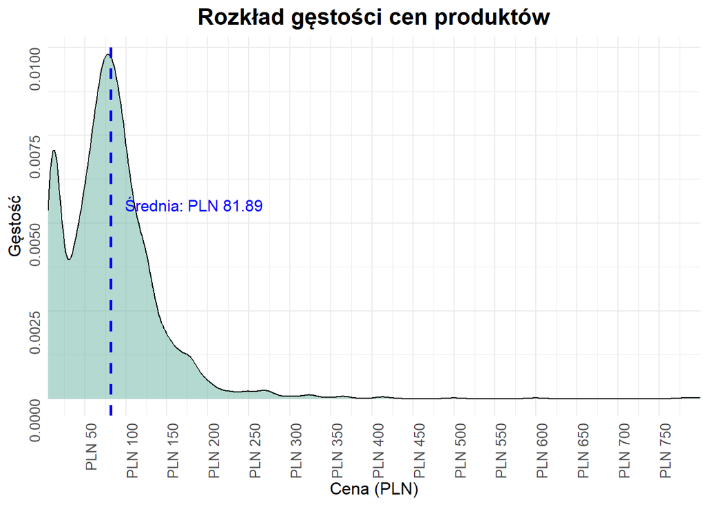

```r
srednia_cena <- mean(dane_df$cena, na.rm = TRUE)

ggplot(dane_df, aes(x = cena)) +
  geom_density(fill = "#69b3a2", alpha = 0.5) +
  geom_vline(xintercept = srednia_cena, color = "blue", linetype = "dashed", linewidth = 1) +
  annotate("text", x = srednia_cena, y = 0.005, label = paste0("Średnia: PLN ", round(srednia_cena, 2)),
           color = "blue", vjust = -1, hjust = -0.1, size = 4) +
  scale_x_continuous(
    labels = scales::dollar_format(prefix = "PLN "),
    breaks = seq(0, max(dane_df$cena, na.rm = TRUE), by = 50),
    expand = c(0, 0)
  ) +
  labs(
    title = "Rozkład gęstości cen produktów",
    x = "Cena (PLN)",
    y = "Gęstość",
  ) +
  theme_minimal() +
  theme(
    plot.title = element_text(hjust = 0.5, size = 16, face = "bold"),
    axis.title = element_text(size = 12),
    axis.text = element_text(size = 10, angle = 90, vjust = 0.5, hjust = 1)
  )
```

Powyższy wykres gęstości przedstawia wyniki analizy rozkładu cen produktów w kategorii “pielęgnacja koreańska”. Można zauważyć że obecne są dwa obszary w których tych produktów jest najwwięcej. W obszarze od 50 do 100 złotych zawiera się zdecydowana większość produktów. Jednak jeśli jest to dla klientów zbyt wysoka półka cenowa obecna jest też pula produktów znacznie poniżej 50 złotych. W sumie średnia cena za produkt w tej kategorii wynosi 81,89 złotych.W skrajnych przypadkach ceny produktów moga sięgać nawet powyżej 750 złotych, jednak są to pojedyncze produkty lub też zestawy produktów, co może tłumaczyć taką cenę.

Patrząc na powyższy wykres gęstości można dojść do wniosku, że “pielęgnacja koreańska” posiada produkty dostosowane do konsumentów o średniej zamożności, utrzymując tym swój prestiżowy i pożądany status. Jednak aby nie zawężać swojego rynku, obecne są także produkty, które odpowiadają niższej pólce cenowej.

## 2. Procentowy udział typów produktów w kategorii

Badanie procentowego udziału typów produktów ma na celu identyfikację najczęściej występujących w tej kategorii produktów. Wybrany sektor obejmuje wiele różnych produktów, od toników, przez esencje, aż po maski i kremy. Zrozumienie, które z tych typów produktów dominują w ofercie, pozwala na lepszą orientację w tym, jaką część rynku zajmują konkretne produkty, a także wskazuje na preferencje konsumentów. Wykres słupkowy przedstawia, które kategorie produktów w pielęgnacji koreańskiej mają największy udział, co może sugerować aktualne trendy w pielęgnacji skóry.

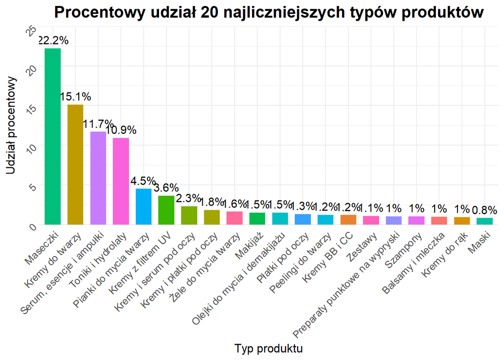

```r
typy_produktow <- dane_df %>%
  count(typ_produktu) %>%
  mutate(procent = n / sum(n) * 100) %>%
  arrange(desc(n)) %>%
  head(20)

ggplot(typy_produktow, aes(x = reorder(typ_produktu, -procent), y = procent, fill = typ_produktu)) +
  geom_bar(stat = "identity", width = 0.7) +
  geom_text(aes(label = paste0(round(procent, 1), "%")),
            vjust = -0.5, size = 4, color = "black") +
  labs(
    title = "Procentowy udział 20 najliczniejszych typów produktów",
    x = "Typ produktu",
    y = "Udział procentowy",
    fill = "Typ produktu"
  ) +
  scale_y_continuous(limits = c(0, 25), expand = c(0, 0)) +
  theme_minimal() +
  theme(
    plot.title = element_text(hjust = 0.5, size = 16, face = "bold"),
    axis.title = element_text(size = 12),
    axis.text = element_text(size = 10, angle = 45, hjust = 1),
    legend.position = "none"
  )
```

Z racji na występowanie prawie 100 kategorii produktów, na wykresie powyżej przedstawione zostało 20 tych najbardziej licznych. Na pierwszy rzuto oka widać, że rynek tego rodzaju pielęgnacji dominują maseczki. Maseczki w płachcie, szczególnie te koreańskich marek, cieszą się bardzo dużą popularnością i są obecnie często wdrażane w rutyny pielęgnacji twarzy. Kolejne najbardziej liczne kategorie w większości dotyczą również skóry twarzy i okolic dekoltu, bo to na tym w większości pielęgnacja koreańska skupia się, przynajmniej w ujęciu pokazywanym przez media.

## 3. Rozkład cenowy dla 5 najpopularniejszych marek

Przedstawienie rozkładu cenowego dla pięciu najpopularniejszych marek ma pokazać, jak kształtują się ceny produktów w różnych segmentach rynku “pielęgnacji koreańskiej”. Analiza polityki cenowej najpopularniejszych marek może dostarczyć informacji, dlaczego są one najbardziej rozpoznawalne i wybierane. Wykorzystując wykres pudełkowy, mogliśmy ocenić, gdzie znajduje się mediana, jaka jest rozpiętość cenowa oraz jakie produkty wykraczają poza standardowy zakres cenowy, stanowiąc tzw. wartości odstające. Mogą to być informacje wartościowe zarówno dla konsumentów oraz dla konkurencyjnych firm/marek, które chciałyby potencjalnie wejść na ten rynek.

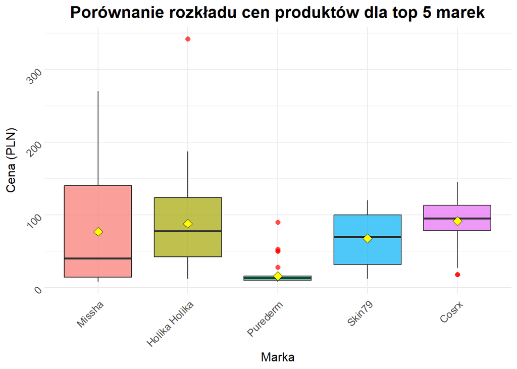

```r
top_marki <- dane_df %>%
  group_by(marka) %>%
  summarise(suma_ocen = sum(liczba_ocen, na.rm = TRUE)) %>%
  arrange(desc(suma_ocen)) %>%
  slice(1:5) %>%
  pull(marka)

dane_top_marki <- dane_df %>%
  filter(marka %in% top_marki) %>%
  mutate(marka = factor(marka, levels = top_marki))

# 3. Tworzenie wykresu pudełkowego
ggplot(dane_top_marki, aes(x = marka, y = cena, fill = marka)) +
  geom_boxplot(outlier.color = "red", outlier.shape = 16, outlier.size = 2, alpha = 0.7) +
  stat_summary(fun = mean, geom = "point", shape = 23, size = 3, fill = "yellow") +
  labs(
    title = "Porównanie rozkładu cen produktów dla top 5 marek",
    x = "Marka",
    y = "Cena (PLN)",
    fill = "Marka"
  ) +
  theme_minimal() +
  theme(
    plot.title = element_text(hjust = 0.5, size = 16, face = "bold"),
    axis.title = element_text(size = 12),
    axis.text = element_text(size = 10, angle = 45, hjust = 1),
    legend.position = "none"
  )
```

Na powyższym wykresie pudełkowym widać przedziały cenowe dla pięciu najpopularniejszych marek z kategorii “pielęgnacja koreańska”. Marki wybrane zostały na podstawie sumarycznej liczby ocen z oferowanych przez siebie produktów.

Dla marki **Missha**, która cieszy się największą liczbą ocen widać, że oferuje najszerszy zakres cen z pozostałych. Nie obserwujemy wartości odstających - oznaczonych jako czerwone punkty. Największa część produktów znajduje się w obrębie od parunastu złotych do niecałych 150. Oprócz Purederm charakteryzuje się również najniższą medianą wśród marek. Szeroki zakres cenowy, przy równoczesnym skupieniu produktów w niższej półce cenowej zapewnia szeroki wybór produktów dla konsumentów z różnym budżetem.

Z kolejna marką, którą jest **Holika Holika**, możemy zauważyć zdecydowane zmniejszenie się zakresu cen oferowanych produktów, jak również wyższą średnią (żółty punkt) oraz medianę. Tendencja zawężania zakresów cenowych widoczna tez jest przy markach takich jak **Skin79** i **Cosrx**.

**Purederm** przyjął taktykę bardzo małego zakresu niskich cen. JEst on dobrą alternatywą dla konsumentów poszukujących tanich zamienników dla droższych kosmetyków, co pozwala plasować mu się na 3 miejscu pod względem liczby opinii.

## 4. Oferta najbardziej ocenianej marki

Dzięki informacji uzyskanej z analizy najpopularniejszych marek, możemy się teraz przyjrzeć bardziej tym co do zaoferowania z produktów ma marka Missha. Może to pomóc w dokładniejszej ocenie polityki prowadzonej przez tą markę oraz zapewnić informacje potencjalnym nowym producentom kosmetyków “pielęgnacji koreańskiej”.

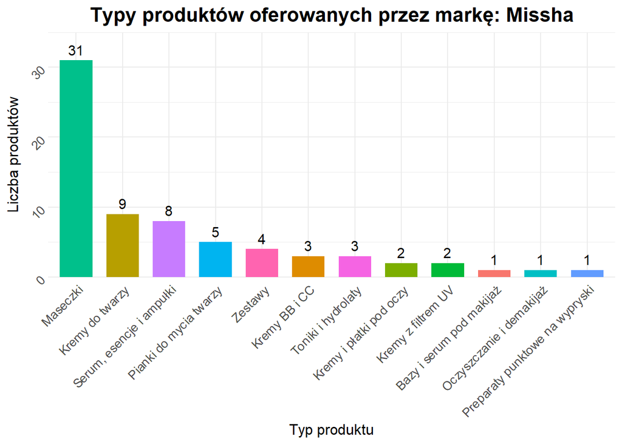

```r
marka_max_ocen <- dane_df %>%
  group_by(marka) %>%
  summarise(suma_ocen = sum(liczba_ocen, na.rm = TRUE)) %>%
  arrange(desc(suma_ocen)) %>%
  slice(1) %>%
  pull(marka)

marka_data <- dane_df %>%
  filter(marka == marka_max_ocen) %>%
  count(typ_produktu)

ggplot(marka_data, aes(x = reorder(typ_produktu, -n), y = n, fill = typ_produktu)) +
  geom_bar(stat = "identity", width = 0.7) +
  geom_text(aes(label = n), vjust = -0.5, size = 4, color = "black") +
  labs(
    title = paste("Typy produktów oferowanych przez markę:", marka_max_ocen),
    x = "Typ produktu",
    y = "Liczba produktów",
    fill = "Typ produktu"
  ) +
  scale_y_continuous(limits = c(0, 35), expand = c(0, 0)) +
  theme_minimal() +
  theme(
    plot.title = element_text(hjust = 0.5, size = 16, face = "bold"),
    axis.title = element_text(size = 12),
    axis.text = element_text(size = 10, angle = 45, hjust = 1),
    legend.position = "none"
  )
```

Przedstawiony wykres potwierdza informacje uzyskane przy ogólnej analizie rynku z badanej kategorii. Maseczki do twarzy stanowią największy odsetek proponowanych produktów również w przypadku pojedynczej marki. Na kolejnych miejscach również znajdują się preparaty do pielęgnacji twarzy. Brak jakichkolwiek produktów do pielęgnacji włosów, czy skóry ciała co może wskazywać na nieopłacalność w produkowaniu kosmetyków tego typu w kategorii “pielęgnacja koreańska”.

## 5. 10 najlepiej ocenianych produktów

Tabela 10 najlepiej ocenianych produktów stanowi podsumowanie produktów, które zdobyły najwyższe oceny użytkowników. Tego typu zestawienie daje wgląd w preferencje konsumentów, którzy w swoich recenzjach docenili skuteczność, jakość, czy cenę produktów. Produkty te mogą stanowić punkt odniesienia dla innych marek, które chcą poprawić swoje oferty lub dla konsumentów szukających najlepszych produktów na rynku. Tabela ta uwzględnia zarówno wysoko oceniane kosmetyki, jak i ich ceny, co pozwala na porównanie popularności z ich wartością rynkową.

```r
top_produkty <- dane_df %>%
  arrange(desc(liczba_ocen), desc(srednia_ocena)) %>%
  select(nazwa, marka, srednia_ocena, liczba_ocen, typ_produktu) %>%
  slice(1:10)

top_produkty %>%
  gt() %>%
  tab_header(
    title = "Top 10 produktów według liczby i średniej oceny"
  ) %>%
  fmt_number(
    columns = c(srednia_ocena), decimals = 2
  ) %>%
  cols_label(
    nazwa = "Nazwa Produktu",
    marka = "Marka",
    srednia_ocena = "Średnia Ocena",
    liczba_ocen = "Liczba Ocen",
    typ_produktu = "Typ Produktu"
  ) %>%
  tab_style(
    style = cell_text(weight = "bold"),
    locations = cells_title(groups = "title")
  ) %>%
  tab_style(
    style = cell_text(style = "italic"),
    locations = cells_column_labels(columns = everything())
  )
```

Top 10 produktów według liczby i średniej oceny

| Nazwa Produktu | Marka | Średnia Ocena | Liczba Ocen | Typ Produktu |
| --- | --- | --- | --- | --- |
| Krem bb z filtrem spf42/pa+++ do twarzy 23 natural beige | Missha | 5.00 | 2997 | Kremy BB i CC |
| Wodoodporny krem-żel przeciwsłoneczny do twarzy spf50 pa++++ | Holika Holika | 5.00 | 2107 | Kremy do twarzy |
| Lekki krem przeciwsłoneczny do twarzy z spf50+ pa++++ | Skin79 | 5.00 | 2035 | Kremy z filtrem UV |
| Kolagenowa maseczka pod oczy | Purederm | 5.00 | 930 | Kremy i serum pod oczy |
| Nawilżająca esencja do twarzy | Cosrx | 5.00 | 894 | Serum, esencje i ampułki |
| Przeciwsłoneczny krem z spf50+ do twarzy | Beauty Of Joseon | 5.00 | 840 | Kremy z filtrem UV |
| Krem bb z filtrem spf42/pa+++ do twarzy 23 natural beige | Missha | 5.00 | 822 | Kremy BB i CC |
| Aloesowy żel do twarzy ciała i włosów | Soqu | 5.00 | 750 | Serum i ampułki |
| Aloesowy żel wielofunkcyjny | Holika Holika | 5.00 | 730 | Balsamy i mleczka |
| Odżywczo-ujędrniający krem do twarzy z jagodami żeń-szenia | Cliv | 5.00 | 582 | Kremy do twarzy |

Pośród przedstawionych powyżej najlepiej ocenianych produktów nie widać dużego trendu wśród marki czy typu produktu. Można jednak dzięki ich nazwą stwierdzić, że wbrew całej struktury rynku pzedstawionej w Analizie, punkcie 2, najlepiej oceniane nie są maseczki do twarzy, a kremy z filtrem spf. “Koreańska pielęgnacja” kładzie bardzo silny nacisk na ochronę przed szkodliwym działaniem promieniowania UV, więc potwierdza to, że produkty nie tyle z kategorii “kremy z filtrem UV”, ale zaopatrzone w to jako bonus sprzedają się najlepiej i dają dużą rozpoznawalność marki.

## 6. Analiza produktów pod względem zawartości potencjalnych alergenów

Alergeny często stanowią istotny czynnik ograniczający dla konsumentów, zwłaszcza dla osób z wrażliwą skórą lub podatnych na reakcje alergiczne. Analiza składu kosmetyków pod kątem obecności takich substancji, jak “fragrance”, “paraben”, “alcohol”, “sodium lauryl sulfate”, “formaldehyde” i “propylene glycol”, pozwala na podejmowanie bardziej świadomych decyzji zakupowych. Dla producentów natomiast może być to wskazówka do opracowywania formuł bardziej przyjaznych dla użytkowników. Z tego powodu warto zwracać na nie szczególną uwagę przy analizie składu kosmetyków.

### 6.1. Wykres ogólnej zawartości alergenów

Wykres ogólnej zawartości alergenów pokazuje, jak duża część produktów w analizowanej kategorii zawiera podane wcześniej alergeny. Analiza ta pokazuje jaki procent kosmetyków jest wolny od zawartości potencjalnych drażniących substancji, a tym samym jest bezpieczny dla alergików.

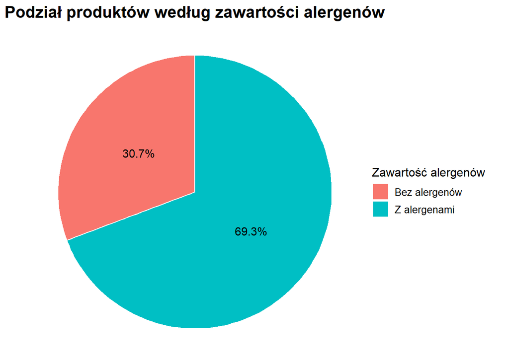

```r
alergeny_podzial <- dane_df %>%
  mutate(czy_zawiera_alergeny = ifelse(is.na(alergeny), "Bez alergenów", "Z alergenami")) %>%
  count(czy_zawiera_alergeny) %>%
  mutate(procent = n / sum(n) * 100)

ggplot(alergeny_podzial, aes(x = "", y = procent, fill = czy_zawiera_alergeny)) +
  geom_col(width = 1, color = "white") +
  coord_polar(theta = "y") +
  geom_text(aes(label = paste0(round(procent, 1), "%")),
            position = position_stack(vjust = 0.5), size = 4) +
  labs(
    title = "Podział produktów według zawartości alergenów",
    fill = "Zawartość alergenów"
  ) +
  theme_void() +
  theme(
    plot.title = element_text(hjust = 0.5, size = 16, face = "bold"),
    legend.title = element_text(size = 12),
    legend.text = element_text(size = 10)
  )
```

Na diagramie kołowym widać, że w kategorii “pielęgnacja koreańska” zaledwie 30,7% oferowanych produktów jest wolnych od potencjalnych substancji alergicznych. Zważając na duży trend w perfumowaniu kosmetyków codziennego użytku, nie jest to mały odsetek, jednak pokazuje to, że potencjalny konsument z nietolerancją na te składniki powinien uważnie przestudiować skład wybranego kosmetyku.

### 6.2. Częstość występowania poszczególnych alergenów

Po zbadaniu jaka częśc kosmetyków jest wolna od wybranych substancji potencjalnie uczulających, warto spojrzeć na to jakie nich występują najczęściej w badanej kategorii. Wykres rozbija grupę kosmetyków zawierających alergeny w celu wizualizacji wyników analizy.

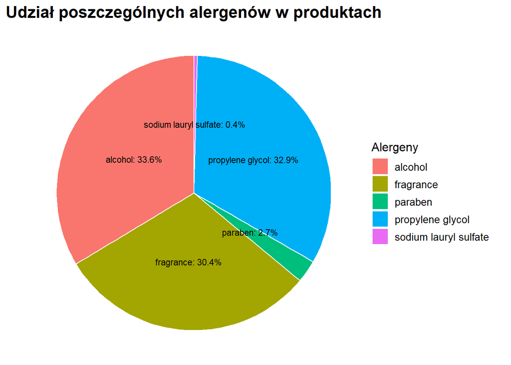

```r
alergeny_szczegoly <- dane_df %>%
  filter(!is.na(alergeny)) %>%
  separate_rows(alergeny, sep = ", ") %>%
  count(alergeny) %>%
  mutate(procent = n / sum(n) * 100)

ggplot(alergeny_szczegoly, aes(x = "", y = procent, fill = alergeny)) +
  geom_col(width = 1, color = "white") +
  coord_polar(theta = "y") +
  geom_text(aes(label = paste0(alergeny, ": ", round(procent, 1), "%")),
            position = position_stack(vjust = 0.5), size = 3) +
  labs(
    title = "Udział poszczególnych alergenów w produktach",
    fill = "Alergeny"
  ) +
  theme_void() +
  theme(
    plot.title = element_text(hjust = 0.5, size = 16, face = "bold"),
    legend.title = element_text(size = 12),
    legend.text = element_text(size = 10)
  )
```